# Modelisation_de_la_consommation_d'electricité

```python
# @hidden_cell
# The project token is an authorization token that is used to access project resources like data sources, connections, and used by platform APIs.
from project_lib import Project
project = Project(project_id='ca8998af-60ec-4af7-a5ee-935daeff58ca', project_access_token='p-1379f525698dc66ee90bcd6b8164145eb35ea2e7')
pc = project.project_context
```

```python
# @hidden_cell
! pip install arch
```

## Importation des Bilbiothèques

```python
import pandas as pd
import numpy as np
import matplotlib.pyplot as plt
import seaborn as sns
import warnings
warnings.filterwarnings("ignore")
sns.set()
```

## Defintion des fonctions des graphes

```python
from statsmodels.graphics.tsaplots import plot_acf, plot_pacf
from statsmodels.tsa.stattools import adfuller
def tsplot(y, ADF=True, lags=None,title=None, figsize=(15, 7), style='bmh'):
    """
        Plot time series, its ACF and PACF, calculate Dickey–Fuller test

        y - timeseries
        lags - how many lags to include in ACF, PACF calculation
    """
    if title == None:
        title = "Time Series Analysis Plots"
    else:
        title = str(title)
    if not isinstance(y, pd.Series):
        y = pd.Series(y)

    with plt.style.context(style):
        fig = plt.figure(figsize=figsize)
        layout = (2, 2)
        ts_ax = plt.subplot2grid(layout, (0, 0), colspan=2)
        acf_ax = plt.subplot2grid(layout, (1, 0))
        pacf_ax = plt.subplot2grid(layout, (1, 1))

        y.plot(ax=ts_ax)
        if ADF == True:
            p_value = adfuller(y)[1]
            ts_ax.set_title(title + '\n Dickey-Fuller: p_value = {0:.5f}'.format(p_value))
        else:
             ts_ax.set_title(title)
        plot_acf(y, lags=lags, ax=acf_ax)
        plot_pacf(y, lags=lags, ax=pacf_ax)
        plt.tight_layout()
```

```python
from statsmodels.graphics.gofplots import qqplot
from statsmodels.graphics.tsaplots import plot_acf, plot_pacf
from statsmodels.tsa.stattools import adfuller
from seaborn import distplot
def tsplot_resid(y, lags=None,title=None, figsize=(15, 7), style='bmh'):
    """
        Plot time series, its ACF and PACF, calculate Dickey–Fuller test

        y - timeseries
        lags - how many lags to include in ACF, PACF calculation
    """
    if title == None:
        title = "Time Series Analysis Plots"
    else:
        title = str(title)
    if not isinstance(y, pd.Series):
        y = pd.Series(y)

    with plt.style.context(style):
        fig = plt.figure(figsize=figsize)
        layout = (3, 2)
        ts_ax = plt.subplot2grid(layout, (0, 0), colspan=2)
        acf_ax = plt.subplot2grid(layout, (1, 0))
        pacf_ax = plt.subplot2grid(layout, (1, 1))
        qqplot_ax = plt.subplot2grid(layout, (2, 0))
        dist_ax = plt.subplot2grid(layout, (2, 1))

        y.plot(ax=ts_ax)
        ts_ax.set_title(title)
        plot_acf(y, lags=lags, ax=acf_ax)
        plot_pacf(y, lags=lags, ax=pacf_ax)
        qqplot(y,fit=True, line="45", ax=qqplot_ax)
        qqplot_ax.set_title("Normalitée")
        distplot(y, ax=dist_ax)
        dist_ax.set_title("Distribution")
        plt.tight_layout()
```

## Importation des données

```python
consommation = project.get_file("Consommation d'électricité.xls")
df = pd.read_excel(consommation, sheet_name = "Algerie", index_col=0)
df = df.transpose()
df.head()
```

| Année | Consommation d'electricité par habitant |
| --- | --- |
| 1971 | 133.873489 |
| 1972 | 142.875928 |
| 1973 | 158.754155 |
| 1974 | 170.660458 |
| 1975 | 195.692277 |

## Traitement des données

```python
df["Année"] = df.index
df.reset_index(inplace=True)
df["Année"] = pd.to_datetime(df["Année"], format="%Y")
df.drop(["index"], axis=1, inplace=True)
df.set_index("Année", inplace = True)
df.head()
```

| Année | Consommation d'electricité par habitant |
| --- | --- |
| 1971-01-01 | 133.873489 |
| 1972-01-01 | 142.875928 |
| 1973-01-01 | 158.754155 |
| 1974-01-01 | 170.660458 |
| 1975-01-01 | 195.692277 |

## Graphique de la serie chronologique

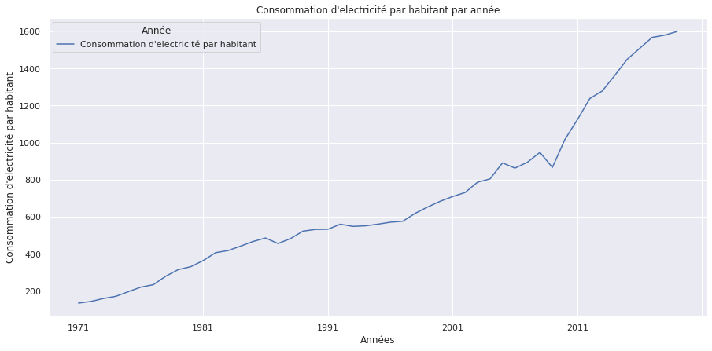

```python
df.plot(figsize=(15,7))
plt.xlabel("Années")
plt.ylabel("Consommation d'electricité par habitant")
plt.title("Consommation d'electricité par habitant par année")
```

## Examination des données

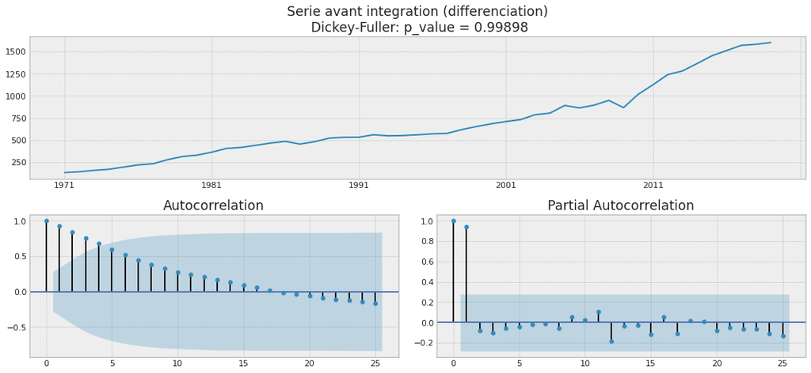

```python
tsplot(df["Consommation d'electricité par habitant"],lags=25, title = "Serie avant integration (differenciation)")
```

- Après avoir appliqué le test de Dickey-Fuller Augmenté, la p_value = 0.99898 > 0.05, ce qui signifie que les données ne sont pas stationnaires.

## Differenciation des données

```python
dff = df.diff()
dff = dff.dropna()
dff.head()
```

| Année | Consommation d'electricité par habitant |
| --- | --- |
| 1972-01-01 | 9.002438 |
| 1973-01-01 | 15.878228 |
| 1974-01-01 | 11.906302 |
| 1975-01-01 | 25.031819 |
| 1976-01-01 | 24.373496 |

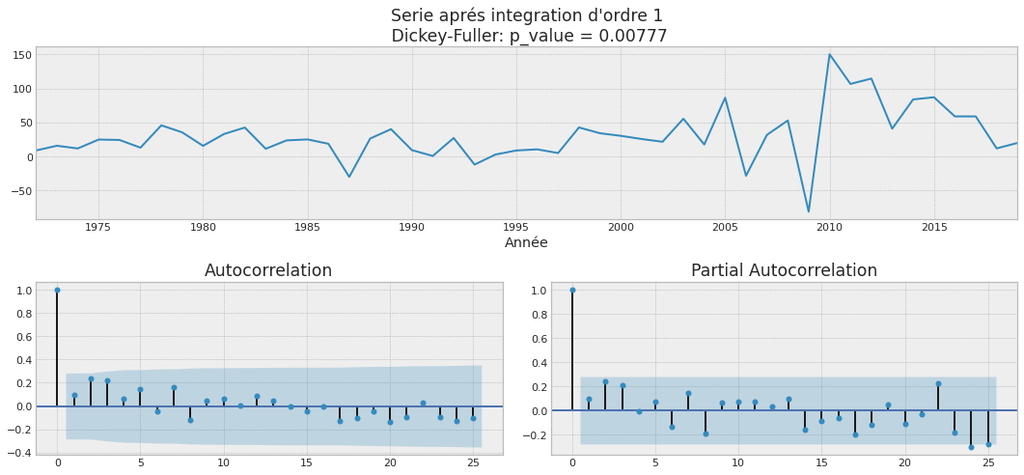

```python
tsplot(dff["Consommation d'electricité par habitant"],lags=25, title="Serie aprés integration d'ordre 1")
```

- La nouvelle série après différenciation est une serie stationnaire selon la p_value du test ADF qui est egale a 0.007 < 0.05
- Aucun pique n'est significatif ni dans la FAC ni dans la FAP
- A première vue, un processus ARIMA(0,1,0) est le meilleure pour cette serie de données

```python
from statsmodels.tsa.arima_model import ARIMA
def _get_best_model(TS):
    best_aic = np.inf
    best_order = None
    best_mdl = None
    pq_rng = range(5) # [0,1,2,3,4]
    d_rng = range(2) # [0,1]
    for i in pq_rng:
        for d in d_rng:
            for j in pq_rng:
                try:
                    tmp_mdl = ARIMA(TS, order=(i,d,j)).fit(
                    )
                    tmp_aic = tmp_mdl.aic
                    if tmp_aic < best_aic:
                        best_aic = tmp_aic
                        best_order = (i, d, j)
                        best_mdl = tmp_mdl
                except: continue
    print('aic: {:6.2f} | order: {}'.format(best_aic, best_order))
    return best_aic, best_order, best_mdl
res_tup = _get_best_model(df)
```

```
aic: 488.37 | order: (0, 1, 0)
```

## Choix du meilleure modèle

```python
def get_best_model_2(TS):
    AIC = []
    order = []
    pq_rng = range(3) # [0,1,2,3,4]
    d_rng = range(1,2) # [0,1]
    for d in d_rng:
        for i in pq_rng:
            for j in pq_rng:
                try:
                    tmp_mdl = ARIMA(TS, order=(i,d,j)).fit()
                    AIC.append(tmp_mdl.aic)
                    order.append((i,d,j))
                except: continue
    tbl = {"Ordre":order, "AIC":AIC}
    rank = pd.DataFrame(tbl)
    rank.sort_values(by=["AIC"], ascending=True, inplace=True)
    rank.set_index("Ordre", inplace=True)
    return rank
```

```python
get_best_model_2(df)
```

| Ordre | AIC |
| --- | --- |
| (0, 1, 0) | 488.371799 |
| (2, 1, 0) | 489.413460 |
| (1, 1, 2) | 489.867997 |
| (0, 1, 2) | 489.879725 |
| (1, 1, 0) | 489.972328 |
| (2, 1, 2) | 490.062727 |
| (0, 1, 1) | 490.093880 |
| (2, 1, 1) | 490.167045 |
| (1, 1, 1) | 492.251340 |

- Selon le critère Akaike (AIC), le meilleur modele est un ARIMA(0,1,0) avec un AIC = 488.37
- Cela confirme notre première hypothèse

## Estimation du modele ARIMA(0,1,0)

```python
modele = ARIMA(df, order=(0,1,0)).fit()
modele.summary()
```

ARIMA Model Results

| Dep. Variable: | D.Consommation d'electricité par habitant | No. Observations: | 48 |
| --- | --- | --- | --- |
| Model: | ARIMA(0, 1, 0) | Log Likelihood | -242.186 |
| Method: | css | S.D. of innovations | 37.585 |
| Date: | Mon, 28 Dec 2020 | AIC | 488.372 |
| Time: | 22:08:33 | BIC | 492.114 |
| Sample: | 01-01-1972 | HQIC | 489.786 |
|  | - 01-01-2019 |  |  |

|  | coef | std err | z | P>\|z\| | [0.025 | 0.975] |
| --- | --- | --- | --- | --- | --- | --- |
| const | 30.5443 | 5.425 | 5.630 | 0.000 | 19.912 | 41.177 |

- La constante du modele est signifiactif

## Examination des Residus

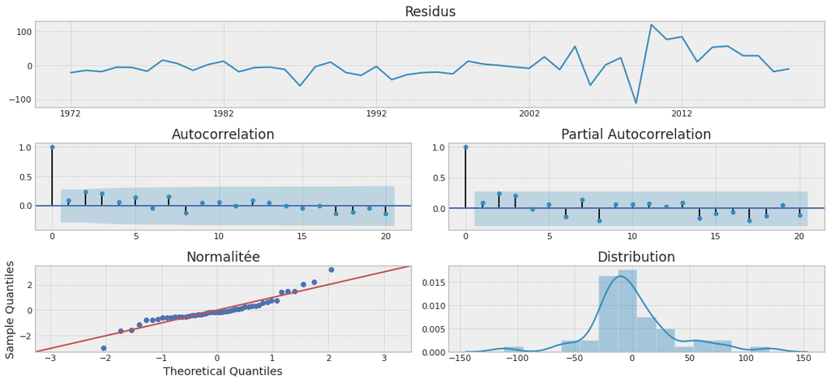

```python
tsplot_resid(modele.resid,lags=20, title="Residus")
```

- A première vue, les residus ont les propriétés d'un Bruit Blanc
- Il n'existe aucun pique significatif dans la FAC et la FAP

### Test ARCH d'Engle pour l'homoscedasticité des Erreurs

#### Ho : Les résidus au carré sont une séquence de bruit blanc - les résidus sont homoscédastiques.

#### H1 : Les résidus au carré n'ont pas pu être ajustés avec un modèle de régression linéaire et présentent une hétéroscédasticité.

```python
from statsmodels.stats.diagnostic import het_arch
print()
print("La valeur critique :",het_arch(modele.resid)[2],",      la p_value :",het_arch(modele.resid)[3])
```

```
La valeur critique : 1.6320909879309025 ,      la p_value : 0.15051916477323907
```

- Étant donné que la p_value est de 0.1505 > 0.05, nous ne parvenons pas à rejeter l'hypothèse nulle, d'ou les résidus sont homoscédastiques
- Donc il n'existe pas d'effet ARCH sur les residus.

### Test de Ljung-Box pour Autocorrelation des Erreurs

#### H0: Les résidus sont distribués indépendamment.

#### HA: les résidus ne sont pas distribués indépendamment; ils présentent une corrélation en série.

```python
from statsmodels.stats.diagnostic import acorr_ljungbox
LB = acorr_ljungbox(modele.resid,lags=[10])
print("statistique =", LB[0][0], "               p_value =",LB[1][0] )
```

```
statistique = 10.181333984986784                p_value = 0.4247309703532606
```

- Étant donné que la p_value est de 0,4247 > 0,05, nous ne parvenons pas à rejeter l'hypothèse nulle, les résidus sont donc distribués indépendamment,
- Ce qui signifie que les résidus ne sont pas autocorrélés

### Test de Jarque-Bera de Normalitée des Erreurs

#### H0 : les données suivent une loi normale.

#### H1 : les données ne suivent pas une loi normale.

```python
from scipy.stats import jarque_bera
JB = jarque_bera(modele_garch.resid)
print("statistic=", JB[0],"           p_value=",JB[1] )
print()
```

[output not shown]

- Puisque la p_value = 0.001 < 0,05, nous rejetons l'hypothèse nulle. Ainsi, nous avons des preuves suffisantes pour dire que ces données ont une asymétrie et un kurtosis qui sont significativement différents d'une distribution normale.
- Donc les erreurs ne suivent pas une loi Normale

## Prevision pur les années 2020 - 2024

```python
pred = modele.forecast(5)
années = [2020, 2021, 2022, 2023, 2024]
df_pred = pd.DataFrame({"Années":années, "Prevision":pred[0]})
df_pred.set_index("Années", inplace=True)
df_pred
```

| Années | Prevision |
| --- | --- |
| 2020 | 1630.544302 |
| 2021 | 1661.088605 |
| 2022 | 1691.632907 |
| 2023 | 1722.177209 |
| 2024 | 1752.721512 |

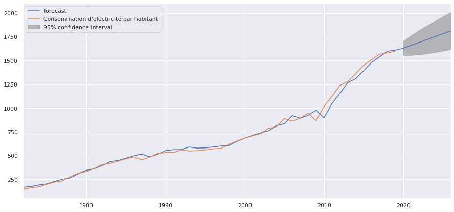

```python
fig, ax = plt.subplots(figsize=(15, 7))
fig = modele.plot_predict(1,55, ax=ax)
```

## Fractionnement des données en données d'entrainement et de test

```python
size = int(len(df)*0.9)
df_train = df.iloc[:size]
df_test = df.iloc[size:]
df_train.tail()
```

| Année | Consommation d'electricité par habitant |
| --- | --- |
| 2010-01-01 | 1016.636669 |
| 2011-01-01 | 1123.332731 |
| 2012-01-01 | 1237.966507 |
| 2013-01-01 | 1278.915343 |
| 2014-01-01 | 1362.871919 |

[figure not shown]

```python
tsplot(df_train["Consommation d'electricité par habitant"],lags=25, title = "Serie avant integration (differenciation)")
```

```python
dif_train = df_train.diff()
dif_train = dif_train.dropna()
dif_train.head()
```

| Année | Consommation d'electricité par habitant |
| --- | --- |
| 1972-01-01 | 9.002438 |
| 1973-01-01 | 15.878228 |
| 1974-01-01 | 11.906302 |
| 1975-01-01 | 25.031819 |
| 1976-01-01 | 24.373496 |

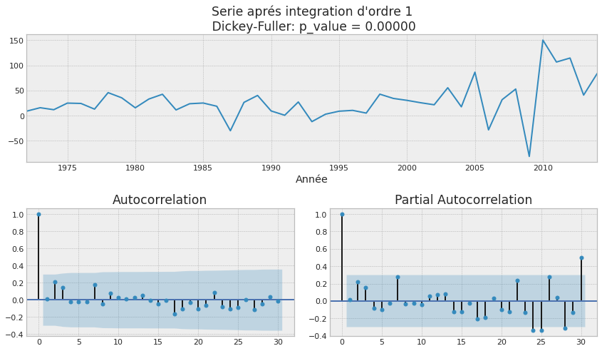

```python
tsplot(dif_train["Consommation d'electricité par habitant"],lags=30, title="Serie aprés integration d'ordre 1")
```

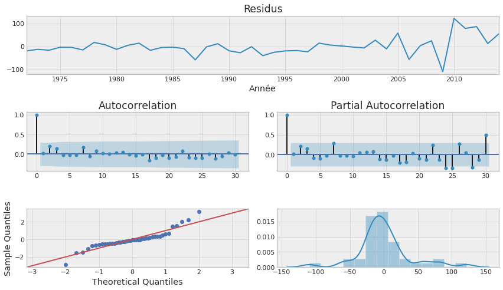

```python
model = ARIMA(df_train, order=(0,1,0)).fit()
tsplot_resid(model.resid,lags=30, title="Residus")
```

Elevation des residus au carré pour detecter la necessité d'un modéle ARCH pour les residus

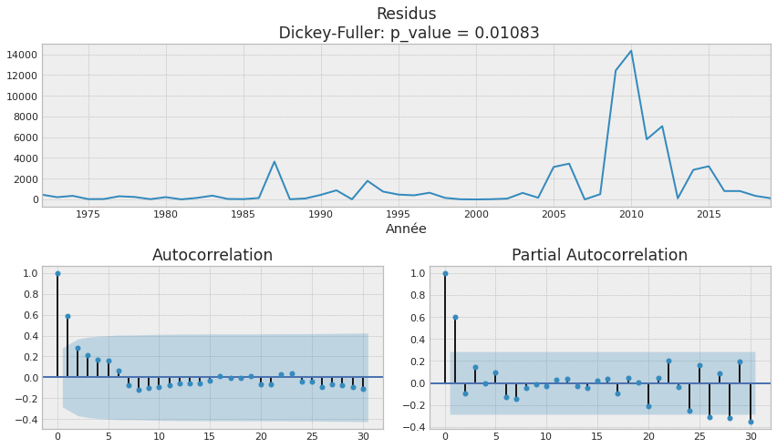

```python
residus_carré = modele.resid**2
tsplot(residus_carré,lags=30, title="Residus")
```

## Estiomation d'un modele GARCH

```python
from arch import arch_model
garch = arch_model(modele.resid,p=1, q=1)
modele_garch = garch.fit(update_freq=5)
modele_garch.summary()
```

```
Iteration:      5,   Func. Count:     28,   Neg. LLF: 231.1705819025867
Iteration:     10,   Func. Count:     53,   Neg. LLF: 231.087220513383
Iteration:     15,   Func. Count:     78,   Neg. LLF: 231.07867542736687
Iteration:     20,   Func. Count:    103,   Neg. LLF: 230.9955093967152
Optimization terminated successfully    (Exit mode 0)
            Current function value: 230.9949613661152
            Iterations: 24
            Function evaluations: 122
            Gradient evaluations: 24
```

Constant Mean - GARCH Model Results

| Dep. Variable: | None | R-squared: | -0.060 |
| --- | --- | --- | --- |
| Mean Model: | Constant Mean | Adj. R-squared: | -0.060 |
| Vol Model: | GARCH | Log-Likelihood: | -230.995 |
| Distribution: | Normal | AIC: | 469.990 |
| Method: | Maximum Likelihood | BIC: | 477.475 |
|  |  | No. Observations: | 48 |
| Date: | Mon, Dec 28 2020 | Df Residuals: | 44 |
| Time: | 20:11:23 | Df Model: | 4 |

Mean Model

|  | coef | std err | t | P>\|t\| | 95.0% Conf. Int. |
| --- | --- | --- | --- | --- | --- |
| mu | -9.2138 | 4.516 | -2.040 | 4.132e-02 | [-18.065, -0.363] |

Volatility Model

|  | coef | std err | t | P>\|t\| | 95.0% Conf. Int. |
| --- | --- | --- | --- | --- | --- |
| omega | 189.8474 | 117.529 | 1.615 | 0.106 | [-40.505,4.202e+02] |
| alpha[1] | 0.3799 | 0.156 | 2.433 | 1.497e-02 | [7.385e-02, 0.686] |
| beta[1] | 0.4789 | 0.185 | 2.593 | 9.503e-03 | [ 0.117, 0.841] |

Covariance estimator: robust

```python
df_train2 = df_train**2
df_train2.head()
```

| Année | Consommation d'electricité par habitant |
| --- | --- |
| 1971-01-01 | 17922.111115 |
| 1972-01-01 | 20413.530678 |
| 1973-01-01 | 25202.881870 |
| 1974-01-01 | 29124.991867 |
| 1975-01-01 | 38295.467311 |

```python
df2 = df**2
df2.head()
```

| Année | Consommation d'electricité par habitant |
| --- | --- |
| 1971-01-01 | 17922.111115 |
| 1972-01-01 | 20413.530678 |
| 1973-01-01 | 25202.881870 |
| 1974-01-01 | 29124.991867 |
| 1975-01-01 | 38295.467311 |

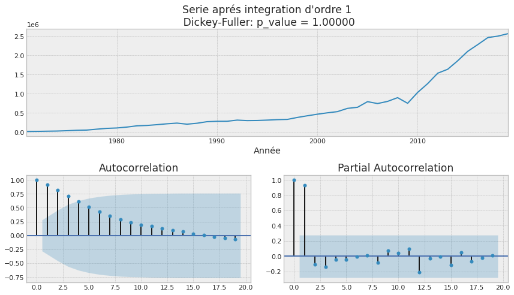

```python
tsplot(df2["Consommation d'electricité par habitant"],lags=19, title="Serie aprés integration d'ordre 1")
```

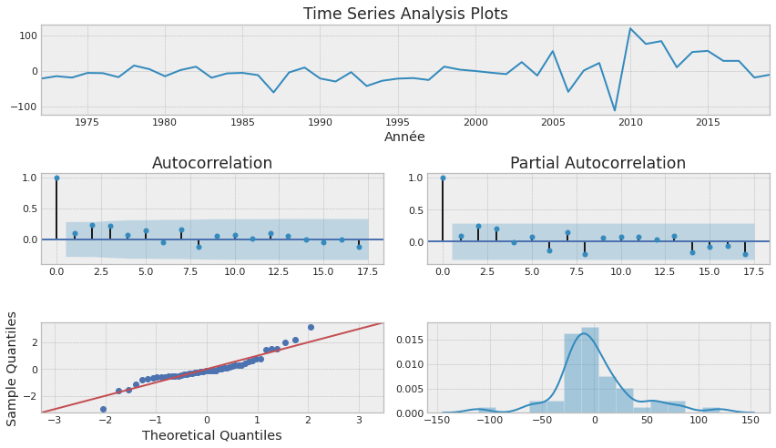

```python
tsplot_resid(modele.resid)
```

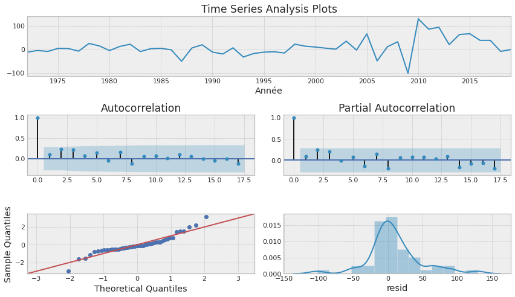

```python
tsplot_resid(modele_garch.resid)
```

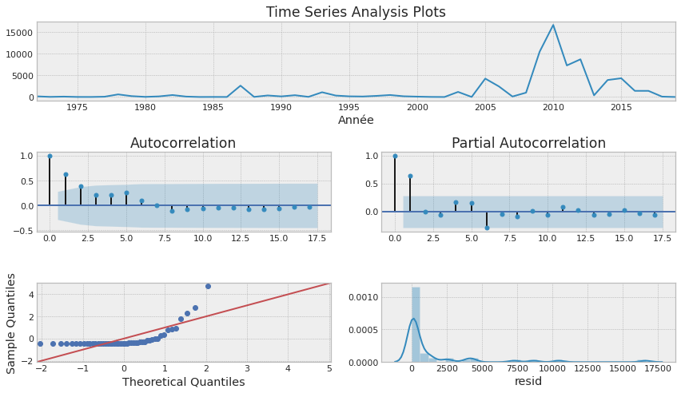

```python
garch2 = modele_garch.resid**2
tsplot_resid(garch2)
```

```python
AIC = []
order = []
for p in range(1,11):
    for q in range(2):
        garch = arch_model(model.resid,p=p, q=q)
        modele_garch = garch.fit(update_freq=50)
        AIC.append(tmp_mdl.aic)
        order.append((p,q))

tbl = {"Ordre":order, "AIC":AIC}
df = pd.DataFrame(tbl)
df
```

```
Optimization terminated successfully    (Exit mode 0)
            Current function value: 229.40434518955567
            Iterations: 16
            Function evaluations: 67
            Gradient evaluations: 16
```

[output not shown]

```python
df.sort_values(by="AIC", ascending=True, inplace=True)
df.head(1)
```

[output not shown]

```python
garch = arch_model(model.resid, vol='GARCH', p=1, q=1)
modele_garch = garch.fit(update_freq=50)
modele_garch.summary()
```

```
Optimization terminated successfully    (Exit mode 0)
            Current function value: 227.68691210273192
            Iterations: 23
            Function evaluations: 117
            Gradient evaluations: 23
```

Constant Mean - GARCH Model Results

[output not shown]

Mean Model

|  | coef | std err | t | P>\|t\| | 95.0% Conf. Int. |
| --- | --- | --- | --- | --- | --- |
| mu | -6.0977 | 4.910 | -1.242 | 0.214 | [-15.721, 3.526] |

Volatility Model

|  | coef | std err | t | P>\|t\| | 95.0% Conf. Int. |
| --- | --- | --- | --- | --- | --- |
| omega | 176.5956 | 114.559 | 1.542 | 0.123 | [-47.935,4.011e+02] |
| alpha[1] | 0.2931 | 0.136 | 2.153 | 3.132e-02 | [2.628e-02, 0.560] |
| beta[1] | 0.5872 | 0.129 | 4.557 | 5.179e-06 | [ 0.335, 0.840] |

Covariance estimator: robust

```python
print("La valeur critique :",het_arch(modele_garch.resid)[0],het_arch(modele_garch.resid)[2] ,",      la p_value :",het_arch(modele_garch.resid)[1],het_arch(modele_garch.resid)[3])
```

```
La valeur critique : 14.583755980836452 1.6915307273492852 ,      la p_value : 0.1479902669312523 0.13637259886661823
```

[figure not shown]

```python
tsplot_resid(modele_garch.resid)
```

```python
AIC = []
order = []
p_val = []
for p in range(1,11):
    for q in range(2):
        garch = arch_model(modele.resid, vol='GARCH', p=p, q=q)
        modele_garch = garch.fit(update_freq=50)
        AIC.append(modele_garch.aic)
        order.append((p,q))
        p_val.append(het_arch(modele_garch.resid)[3])
tbl = {"Ordre":order,"P_val":p_val, "AIC":AIC}
df = pd.DataFrame(tbl)
df.sort_values(by="P_val", ascending=True, inplace=True)
```

[output not shown]

[output cut: 45 more lines]

```
Optimization terminated successfully    (Exit mode 0)
            Current function value: 230.00531780911427
            Iterations: 30
            Function evaluations: 395
            Gradient evaluations: 30
Optimization terminated successfully    (Exit mode 0)
            Current function value: 230.00531735473038
            Iterations: 31
            Function evaluations: 409
            Gradient evaluations: 31
Optimization terminated successfully    (Exit mode 0)
            Current function value: 230.00531741232135
            Iterations: 28
            Function evaluations: 397
            Gradient evaluations: 28
```

```python
df.sort_values(by="AIC", ascending=True, inplace=True)
df
```

[output not shown]